# Generalized Linear Mixed Models: Binomial

## Generalized Linear Model - Binomial

**=Logistic Regression**

- Remember the binomial distribution
- Series of "coin-flip" trials
- Count the total number of an outcome ("heads") in a series of \(N\) trials ("coin flips")
- Estimate the Pr(heads) and factors that influence that
- Presence-Absence or detection-nondetection data

## Logistic Regression

1. Distribution: \(C_i \sim Binomial(N, p_i)\)
2. Link Function: \(logit(p_i) = log\big(\frac{p_i}{1 - p_i}\big) = linear predictor\)
3. Linear Predictor: \(logit(p_i) = \alpha + \beta X_i\)

Let's try it

## Data Generation

Two species (Cross-leaved gentian & Chiltern gentian) with P/A data from 50 sites

```r
N <- 50
p.cr <- 13/50 # avg prob of finding
p.ch <- 29/50 # avg prob of finding

C.cr <- rbinom(1, 50, prob = p.cr) # add binomial noise
C.ch <- rbinom(1, 50, prob = p.ch) # add binomial noise
C <- c(C.cr, C.ch)
species <- factor(c(0,1), labels = c("Cross-leaved", "Chiltern"))
```

## Analysis

Check if a significant difference in the distribution (freq of occurrence)

```r
summary(glm(cbind(C, N-C) ~ species, family = "binomial"))
```

```
##
## Call:
## glm(formula = cbind(C, N - C) ~ species, family = "binomial")
##
## Deviance Residuals:
## [1]  0  0
##
## Coefficients:
##                 Estimate Std. Error z value Pr(>|z|)
## (Intercept)      -0.9445     0.3150  -2.999 0.002712 **
## speciesChiltern   1.4340     0.4291   3.342 0.000831 ***
## ---
## Signif. codes:  0 '***' 0.001 '**' 0.01 '*' 0.05 '.' 0.1 ' ' 1
##
## (Dispersion parameter for binomial family taken to be 1)
##
##     Null deviance: 1.1926e+01  on 1  degrees of freedom
## Residual deviance: 5.5511e-15  on 0  degrees of freedom
## AIC: 12.477
##
## Number of Fisher Scoring iterations: 3
```

```r
predict(glm(cbind(C, N-C) ~ species, family = "binomial"), type = "response")
```

```
##    1    2
## 0.28 0.62
```

## Binomial GLMM

Random intercept and slope

1. Distribution: \(C_i \sim Binomial(N_i, p_i)\)
2. Link Function: \(logit(p_i) = log\big(\frac{p_i}{1 - p_i}\big) = linear predictor\)
3. Linear Predictor: \(logit(p_i) = \alpha_{j(i)} + \beta_{j(i)} X_{i}\)

\[ \alpha_j \sim \mathcal{N}(\mu_{\alpha}, \sigma_{\alpha}^2) \]

\[ \beta_j \sim \mathcal{N}(\mu_{\beta}, \sigma_{\beta}^2) \]

## Example: Generate Data

```r
n.groups <- 16
n.years <- 30
n <- n.groups * n.years
pop <- gl(n = n.groups, k = n.years)
```

Uniform covariate as an index of spring precipitation (0 = little rain, 1 = lots)

```r
precip <- runif(n, 0, 1)
```

Binomial total = number of nest attempts in survey year \(i\)

```r
N <- round(runif(n, 10, 50))
```

Build the design matrix

```r
Xmat <- model.matrix(~pop*precip-1-precip)
```

Choose parameter values and hyperparameters

```r
intercept.mean <- 1         # Select hyperparams
intercept.sd <- 1
slope.mean <- -2
slope.sd <- 1
intercept.effects<-rnorm(n = n.groups, mean = intercept.mean, sd = intercept.sd)
slope.effects <- rnorm(n = n.groups, mean = slope.mean, sd = slope.sd)
all.effects <- c(intercept.effects, slope.effects) # Put them all together
```

Assemble to make the linear predictor and visualize

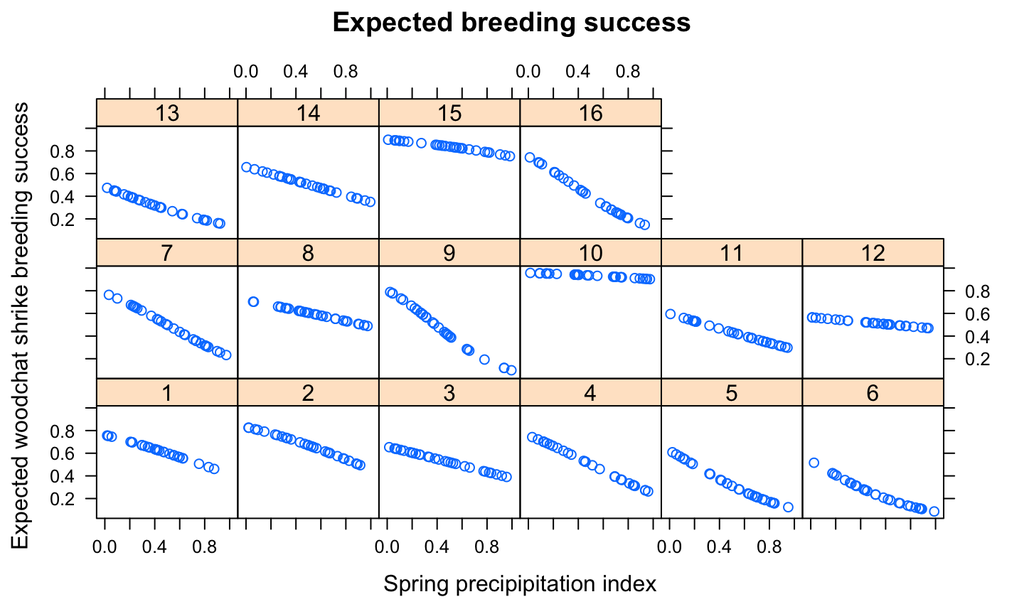

```r
lin.pred <- Xmat %*% all.effects    # Value of lin.predictor
exp.p <- exp(lin.pred) / (1 + exp(lin.pred)) # Expected proportion

library("lattice")
xyplot(exp.p ~ precip | pop, ylab = "Expected woodchat shrike breeding success ",
xlab = "Spring precipipitation index", main = "Expected breeding success")
```

Add random binomial variation

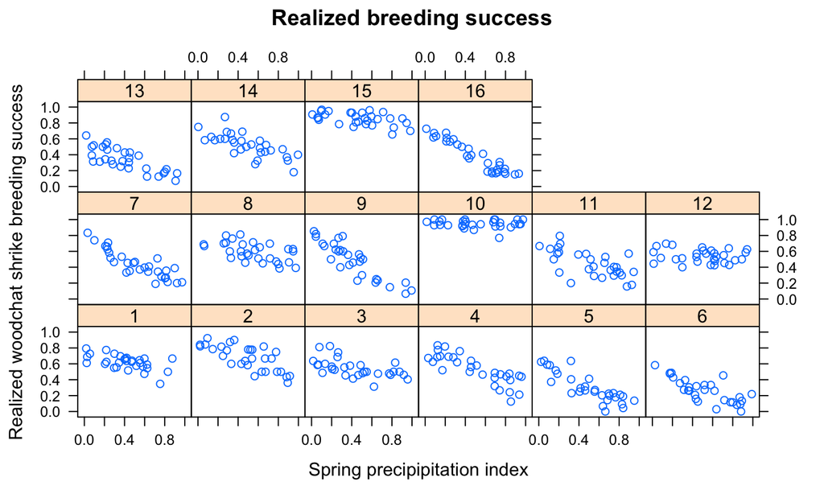

```r
C <- rbinom(n = n, size = N, prob = exp.p) # Add binomial variation
xyplot(C/N ~ precip | pop, ylab = "Realized woodchat shrike breeding success ",
xlab = "Spring precipipitation index", main = "Realized breeding success")
```

## Analysis under a random-coefficients model

Assume no correlation between intercept and slope

```r
library('lme4')
glmm.fit <- glmer(cbind(C, N-C) ~ precip + (1 | pop) + ( 0+ precip | pop), family = binomial)
summary(glmm.fit)
```

```
## Generalized linear mixed model fit by maximum likelihood (Laplace
##   Approximation) [glmerMod]
##  Family: binomial  ( logit )
## Formula: cbind(C, N - C) ~ precip + (1 | pop) + (0 + precip | pop)
##
##      AIC      BIC   logLik deviance df.resid
##   2296.5   2313.2  -1144.2   2288.5      476
##
## Scaled residuals:
##      Min       1Q   Median       3Q      Max
## -2.44898 -0.66683  0.02929  0.71809  2.67255
##
## Random effects:
##  Groups Name        Variance Std.Dev.
##  pop    (Intercept) 0.5827   0.7633
##  pop.1  precip      0.9008   0.9491
## Number of obs: 480, groups:  pop, 16
##
## Fixed effects:
##             Estimate Std. Error z value Pr(>|z|)
## (Intercept)   1.0617     0.1952   5.439 5.34e-08 ***
## precip       -1.8369     0.2491  -7.376 1.64e-13 ***
## ---
## Signif. codes:  0 '***' 0.001 '**' 0.01 '*' 0.05 '.' 0.1 ' ' 1
##
## Correlation of Fixed Effects:
##        (Intr)
## precip -0.056
```

## Activity

Use the `DeerEcervi.txt` data and run a binomial GLMM including random intercepts by farm and fixed (non-random) independent predictor variables for Length, Sex, and Length x Sex.